# **Dimensionality and Reduction Techniques**

For this exercise I use the newly created dataset *human*, which is based on the two datasets *hd* and *gii* from the *Human Development Index*. The original datasets consisted of 195 observations each, the hd-dataset originally included 7 observations, while the gii-dataset included 10 variables.

Four variables of the dataset were reduced to the number of two by combining the separate variables Edu2.F and Edu2.M to Edu2.FM and the separate variables to Lab.FM.

In order to create the dataset *human* the two sets have been joined by the variable *country*. The final seven observations have been removed, as they referred to the regions World, Sub-Saharan Africa, South Asia, Latin America and the Caribbean, Europe and Central Asia, East Asia and the Pacific, and Arab States, and as such not to specific countries.

As can be seen below the dataset *human* now consists of the following 8 variables:

- **Life_Exp** refers to average life-expectency in the number of years from the date of birth
- **Exp_y_Edu** refers to the expected number of educational years
- **GNIpCap** refers to the Gross national income (GNI) per capita
- **MatMorRatio** refers to the Maternal mortality ratio
- **Adol_Birth_Rate** refers to the Adolescent birth rate
- **ParlRepPercent** refers to the women’s share of seats in parliament
- **Edu2.FM** refers to the population with at least some secondary education for both males and females of the age of at least 25)
- **Lab.FM** refers to the Labour force participation rate (for both males and females of the age of 15 or older)

And the dataset itself now consists of 155 observations.

Accessing libraries and loading the dataset “human”:

```r
#activating libraries:
library(tidyr)
library(corrplot)
library(ggplot2)
library(dplyr)
library(GGally)
#loading human:
human <- read.csv("C:\\Users\\Ani\\Documents\\GitHub\\IODS-project\\data\\human.csv", header=TRUE, row.names = 1)
```

Here we take a quick look at the structure and dimensions of the dataset, which are sorted by the name of the country:

```r
str(human)
```

```
## 'data.frame':    155 obs. of  8 variables:
##  $ Life_Exp       : num  81.6 82.4 83 80.2 81.6 80.9 80.9 79.1 82 81.8 ...
##  $ Exp_y_Edu      : num  17.5 20.2 15.8 18.7 17.9 16.5 18.6 16.5 15.9 19.2 ...
##  $ GNIpCap        : Factor w/ 155 levels "1,123","1,228",..: 132 109 124 112 113 111 103 123 108 93 ...
##  $ MatMorRatio    : int  4 6 6 5 6 7 9 28 11 8 ...
##  $ Adol_Birth_Rate: num  7.8 12.1 1.9 5.1 6.2 3.8 8.2 31 14.5 25.3 ...
##  $ ParlRepPercent : num  39.6 30.5 28.5 38 36.9 36.9 19.9 19.4 28.2 31.4 ...
##  $ Edu2.FM        : num  1.007 0.997 0.983 0.989 0.969 ...
##  $ Lab.FM         : num  0.891 0.819 0.825 0.884 0.829 ...
```

```r
dim(human)
```

```
## [1] 155   8
```

Let’s take a brief look at the individual variables of the dataset “human”:

```r
summary(human$Life_Exp)
```

```
##    Min. 1st Qu.  Median    Mean 3rd Qu.    Max.
##   49.00   66.30   74.20   71.65   77.25   83.50
```

```r
summary(human$Exp_y_Edu)
```

```
##    Min. 1st Qu.  Median    Mean 3rd Qu.    Max.
##    5.40   11.25   13.50   13.18   15.20   20.20
```

```r
summary(human$GNIpCap)
```

```
##   1,123   1,228   1,428   1,458   1,507   1,583   1,591   1,613   1,615
##       1       1       1       1       1       1       1       1       1
##   1,669   1,767   1,780   1,885  10,404  10,512  10,605  10,729  11,015
##       1       1       1       1       1       1       1       1       1
##  11,365  11,780  11,883  12,040  12,122  12,190  12,328  12,488  12,547
##       1       1       1       1       1       1       1       1       1
## 123,124  13,054  13,323  13,413  14,003  14,558  14,911  15,175  15,440
##       1       1       1       1       1       1       1       1       1
##  15,596  15,617  16,056  16,159  16,367  16,428  16,509  16,646  16,676
##       1       1       1       1       1       1       1       1       1
##  17,470  18,108  18,192  18,677  19,283  19,409   2,085   2,188   2,311
##       1       1       1       1       1       1       1       1       1
##   2,411   2,463   2,517   2,728   2,762   2,803   2,949  20,867  21,290
##       1       1       1       1       1       1       1       1       1
##  21,336  22,050  22,281  22,352  22,762  22,916  23,177  24,500  24,524
##       1       1       1       1       1       1       1       1       1
##  25,214  25,757  25,845  26,090  26,660  27,852  27,930  28,633   3,044
##       1       1       1       1       1       1       1       1       1
##   3,171   3,191   3,306   3,519   3,560   3,734   3,809   3,852   3,938
##       1       1       1       1       1       1       1       1       1
##  30,676  32,045  32,689  33,030  33,890  34,858  35,182  36,927  38,056
##       1       1       1       1       1       1       1       1       1
## (Other)
##      56
```

```r
summary(human$MatMorRatio)
```

```
##    Min. 1st Qu.  Median    Mean 3rd Qu.    Max.
##     1.0    11.5    49.0   149.1   190.0  1100.0
```

```r
summary(human$Adol_Birth_Rate)
```

```
##    Min. 1st Qu.  Median    Mean 3rd Qu.    Max.
##    0.60   12.65   33.60   47.16   71.95  204.80
```

```r
summary(human$ParlRepPercent)
```

```
##    Min. 1st Qu.  Median    Mean 3rd Qu.    Max.
##    0.00   12.40   19.30   20.91   27.95   57.50
```

```r
summary(human$Edu2.FM)
```

```
##    Min. 1st Qu.  Median    Mean 3rd Qu.    Max.
##  0.1717  0.7264  0.9375  0.8529  0.9968  1.4967
```

```r
summary(human$Lab.FM)
```

```
##    Min. 1st Qu.  Median    Mean 3rd Qu.    Max.
##  0.1857  0.5984  0.7535  0.7074  0.8535  1.0380
```

As I had some trouble that I could not solve in my attempts I have **excluded the variable “GNIpCap” from being visualized in the following graph**. I am aware that it was not part of the task, but even after asking for help in the course-session, I could not get this to work. Thus I had 2 options at this point: 1. including this variable, and changing the “cardinality threshold” to NULL, which would have resulted in unreadable graphs, or 2. excluding the variable GNIpCap from being displayed at all, but at least being able to see the other correlations.

*I assume, that the problem is to be found in my coding [here](https://github.com/JoaWe/IODS-project/blob/master/data/create_human.R) row 54-58. But I have been unable to determine what it is. As you might have noticed in the str() of my dataset the variable still contains characters, although they were supposed to have been changed to numerics. But as I have followed the instructions from the datacamp-exercise, I don’t know why it would not work.*

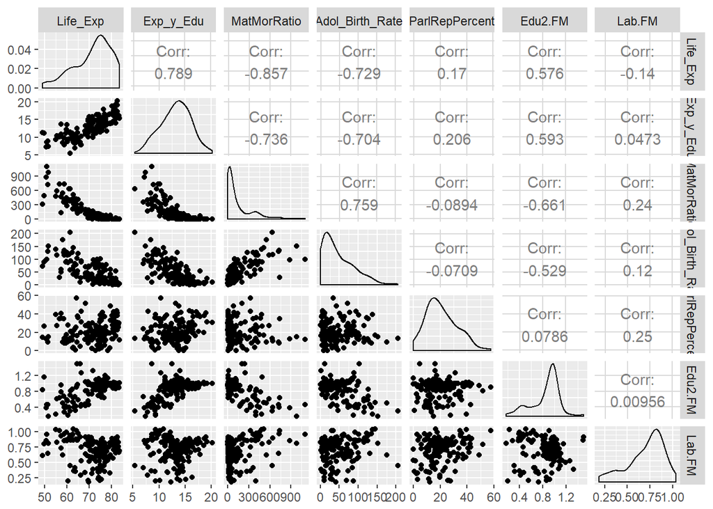

```r
human <- select(human, -GNIpCap)
ggpairs(human)
```

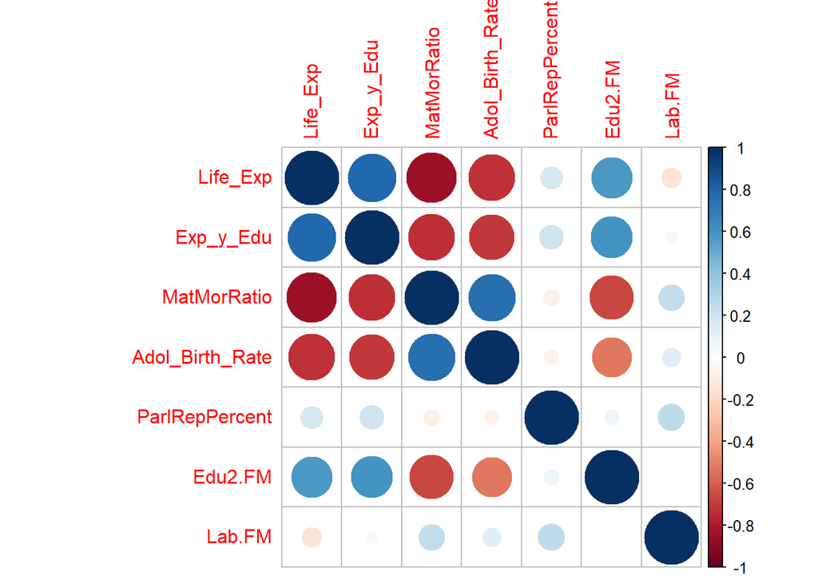

```r
cor(human)%>%corrplot
```

As the graph above shows, there seems to be a very high negative correlation between the Maternal Mortality Ratio (= MatMorRatio) and the general Life-Expectancy (= Life_Exp). Not quite as significant as the former, but certainly noticeable are the strong negative correlations between, firstly, the Maternal Mortality Ratio and the expected number of educational years (= Exp_y_Edu), secondly, the Life Expectancy and the adolescent birthrate (Adol_Birth_Rate), and finally, the negative correlation between the adolescent birthrate and the expected number of educational years.

At this point, the srong positive correlation between the adolsecent birthrate and the Maternal Mortality Ratio appear of little surprise. Equally strong, it seems is the positive correlation between the life expectency and the expected number of educational years.

### Attempting PCA

1. Standardizing the dataset:

```r
human_std <- scale(human)
```